# Analyzing IMDB Data in Keras

```python
# Imports
import numpy as np
import keras
from keras.datasets import imdb
from keras.models import Sequential
from keras.layers import Dense, Dropout, Activation
from keras.preprocessing.text import Tokenizer
import matplotlib.pyplot as plt
%matplotlib inline

np.random.seed(42)
```

## 1. Loading the data

This dataset comes preloaded with Keras, so one simple command will get us training and testing data. There is a parameter for how many words we want to look at. We've set it at 1000, but feel free to experiment.

```python
# Loading the data (it's preloaded in Keras)
(x_train, y_train), (x_test, y_test) = imdb.load_data(num_words=1000)

print(x_train.shape)
print(x_test.shape)
```

[output not shown]

## 2. Examining the data

Notice that the data has been already pre-processed, where all the words have numbers, and the reviews come in as a vector with the words that the review contains. For example, if the word 'the' is the first one in our dictionary, and a review contains the word 'the', then there is a 1 in the corresponding vector.

The output comes as a vector of 1's and 0's, where 1 is a positive sentiment for the review, and 0 is negative.

```python
print(x_train[0])
print(y_train[0])
```

```
[1, 14, 22, 16, 43, 530, 973, 2, 2, 65, 458, 2, 66, 2, 4, 173, 36, 256, 5, 25, 100, 43, 838, 112, 50, 670, 2, 9, 35, 480, 284, 5, 150, 4, 172, 112, 167, 2, 336, 385, 39, 4, 172, 2, 2, 17, 546, 38, 13, 447, 4, 192, 50, 16, 6, 147, 2, 19, 14, 22, 4, 2, 2, 469, 4, 22, 71, 87, 12, 16, 43, 530, 38, 76, 1…
1
```

Here, we'll turn the input vectors into (0,1)-vectors. For example, if the pre-processed vector contains the number 14, then in the processed vector, the 14th entry will be 1.

```python
# One-hot encoding the output into vector mode, each of length 1000
tokenizer = Tokenizer(num_words=1000)
x_train_tok = tokenizer.sequences_to_matrix(x_train, mode='binary')
x_test_tok = tokenizer.sequences_to_matrix(x_test, mode='binary')
print(x_train_tok[0])
```

[output not shown]

```python
print(x_train_tok.shape)
```

```
(25000, 1000)
```

And we'll also one-hot encode the output.

```python
# One-hot encoding the output
num_classes = 2
y_train_tok = keras.utils.to_categorical(y_train, num_classes)
y_test_tok = keras.utils.to_categorical(y_test, num_classes)
print(y_train_tok.shape)
print(y_test_tok.shape)
```

```
(25000, 2)
(25000, 2)
```

```python
y_train_tok = y_train_tok[:, 1]
y_test_tok = y_test_tok[:, 1]
```

```python
print(y_train_tok.shape)
print(y_test_tok.shape)
```

```
(25000,)
(25000,)
```

```python
y_train_tok = np.reshape(y_train_tok, (y_train_tok.shape[0], 1))
y_test_tok = np.reshape(y_test_tok, (y_test_tok.shape[0], 1))
```

```python
y_train_tok
```

```
array([[ 1.],
       [ 0.],
       [ 0.],
       ...,
       [ 0.],
       [ 1.],
       [ 0.]])
```

## 4. Building the model architecture

Build a model here using sequential. Feel free to experiment with different layers and sizes! Also, experiment adding dropout to reduce overfitting.

```python
# TODO: Build the model architecture
from keras.callbacks import EarlyStopping
from keras import optimizers
from keras.optimizers import SGD

def construct_model(optimizer=object):
    model = Sequential()
    model.add(Dense(1000, activation='relu', input_dim=1000))
    model.add(Dropout(0.5))
    model.add(Dense(500, activation='relu'))
    model.add(Dropout(0.5))
    model.add(Dense(1, activation='sigmoid'))
    # to compile the model using a loss function and an optimizer.
    model.compile(loss='binary_crossentropy',
              optimizer=optimizer,
              metrics=['accuracy'])
    return model
```

```python
sgd = SGD(lr=0.005, decay=1e-6, momentum=0.9, nesterov=True)
model = construct_model(optimizer=sgd)
model.summary()
```

```
_________________________________________________________________
Layer (type)                 Output Shape              Param #
=================================================================
dense_13 (Dense)             (None, 1000)              1001000
_________________________________________________________________
dropout_9 (Dropout)          (None, 1000)              0
_________________________________________________________________
dense_14 (Dense)             (None, 500)               500500
_________________________________________________________________
dropout_10 (Dropout)         (None, 500)               0
_________________________________________________________________
dense_15 (Dense)             (None, 1)                 501
=================================================================
Total params: 1,502,001
Trainable params: 1,502,001
Non-trainable params: 0
_________________________________________________________________
```

## 5. Training the model

Run the model here. Experiment with different batch_size, and number of epochs!

```python
# TODO: Run the model. Feel free to experiment with different batch sizes and number of epochs.
from keras.callbacks import ModelCheckpoint

checkpointer = ModelCheckpoint('./weights.hdf5', monitor='val_acc', verbose=1,
                               save_best_only=True, mode='max')

hist = model.fit(x_train_tok, y_train_tok,
                 batch_size=32,
                 epochs=15,
                 validation_data=(x_test_tok, y_test_tok),
                 callbacks=[checkpointer],
                 verbose=0)
```

```
Epoch 00000: val_acc improved from -inf to 0.84156, saving model to ./weights.hdf5
Epoch 00001: val_acc improved from 0.84156 to 0.85732, saving model to ./weights.hdf5
Epoch 00002: val_acc improved from 0.85732 to 0.85852, saving model to ./weights.hdf5
Epoch 00003: val_acc improved from 0.85852 to 0.86092, saving model to ./weights.hdf5
Epoch 00004: val_acc did not improve
Epoch 00005: val_acc did not improve
Epoch 00006: val_acc did not improve
Epoch 00007: val_acc did not improve
Epoch 00008: val_acc did not improve
Epoch 00009: val_acc did not improve
Epoch 00010: val_acc did not improve
Epoch 00011: val_acc did not improve
Epoch 00012: val_acc did not improve
Epoch 00013: val_acc did not improve
Epoch 00014: val_acc did not improve
```

```python
def plot_history(hist, title=''):
    ##
    plt.plot(hist.history['acc'])
    plt.plot(hist.history['val_acc'])
    plt.title('model accuracy')
    plt.ylabel('accuracy')
    plt.xlabel('epoch')
    plt.title(title)
    plt.legend(['train', 'validation'], loc='upper left')
    plt.show()
    ##
    plt.plot(hist.history['loss'])
    plt.plot(hist.history['val_loss'])
    plt.title('model loss')
    plt.ylabel('loss')
    plt.xlabel('epoch')
    plt.title(title)
    plt.legend(['train', 'validation'], loc='upper left')
    plt.yscale('log')
    plt.show()
    ##
    return
```

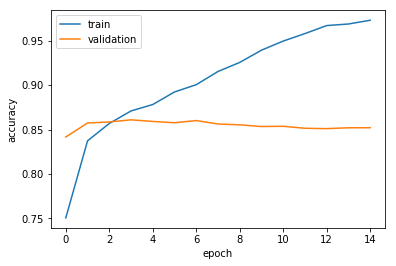

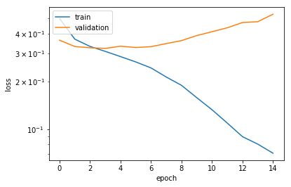

```python
plot_history(hist=hist)
```

## 6. Evaluating the model

This will give you the accuracy of the model, as evaluated on the testing set. Can you get something over 85%?

```python
def evaluate_model(model_builder=construct_model, optimizer=sgd, weights='weights.hdf5',
                  x_val=x_test_tok, y_val=y_test_tok):
    ##
    model = model_builder(optimizer=optimizer)
    model.load_weights(weights)
    score = model.evaluate(x_val, y_val, verbose=0)
    ##
    return print("Accuracy: ", score[1])
```

```python
evaluate_model()
```

```
Accuracy:  0.86092
```

## 7. Changing Optimizer

Here we change the optimizer to adam.

```python
from keras.optimizers import Adam

adam = Adam(lr=0.0003)
model_2 = construct_model(optimizer=adam)
```

```python
checkpointer = ModelCheckpoint('./weights_2.hdf5', monitor='val_acc', verbose=1,
                               save_best_only=True, mode='max')

hist_2 = model_2.fit(x_train_tok, y_train_tok,
                 batch_size=32,
                 epochs=15,
                 validation_data=(x_test_tok, y_test_tok),
                 callbacks=[checkpointer],
                 verbose=0)
```

```
Epoch 00000: val_acc improved from -inf to 0.85384, saving model to ./weights_2.hdf5
Epoch 00001: val_acc improved from 0.85384 to 0.86208, saving model to ./weights_2.hdf5
Epoch 00002: val_acc did not improve
Epoch 00003: val_acc did not improve
Epoch 00004: val_acc did not improve
Epoch 00005: val_acc did not improve
Epoch 00006: val_acc did not improve
Epoch 00007: val_acc did not improve
Epoch 00008: val_acc did not improve
Epoch 00009: val_acc did not improve
Epoch 00010: val_acc did not improve
Epoch 00011: val_acc did not improve
Epoch 00012: val_acc did not improve
Epoch 00013: val_acc did not improve
Epoch 00014: val_acc did not improve
```

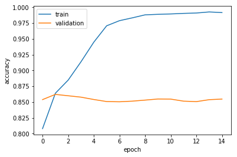

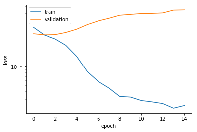

```python
plot_history(hist=hist_2)
```

```python
evaluate_model(model_builder=construct_model, optimizer=adam, weights='weights_2.hdf5')
```

```
Accuracy:  0.86208
```